# Laboratorio n° 3

Oscar Centeno Mora

Tomorrow never dies

# Medias móviles, descomposición, modelos exponenciales y los ETS() en las series temporales univariadas

## La media móvil

### *La media móvil clásica*

Vamos a Utilizar los datos de las ventas anuales de electricidad en Australia. El dataset se llama elecsales

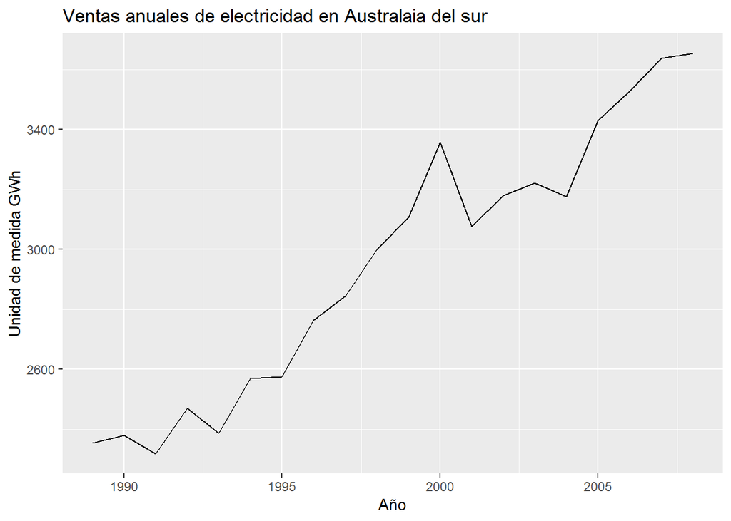

```r
autoplot(elecsales) + xlab("Año") + ylab("Unidad de medida GWh") +
  ggtitle("Ventas anuales de electricidad en Australaia del sur")
```

Apliquemos una media movil simple de orden 5

```r
ma(elecsales, 5)
```

```
## Time Series:
## Start = 1989
## End = 2008
## Frequency = 1
##  [1]       NA       NA 2381.530 2424.556 2463.758 2552.598 2627.700
##  [8] 2750.622 2858.348 3014.704 3077.300 3144.520 3188.700 3202.320
## [15] 3216.940 3307.296 3398.754 3485.434       NA       NA
```

La visualización de la media móvil simple en las Ventas anuales de electricidad en Australaia es la siguiente.

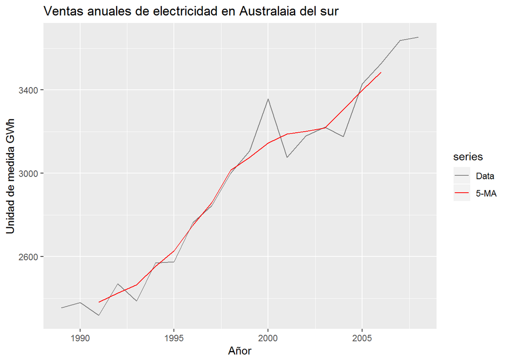

```r
autoplot(elecsales, series="Data") +
  autolayer(ma(elecsales,5), series="5-MA") +
  xlab("Añor") + ylab("Unidad de medida GWh") +
  ggtitle("Ventas anuales de electricidad en Australaia del sur") +
  scale_colour_manual(values=c("Data"="grey50","5-MA"="red"),
                      breaks=c("Data","5-MA"))
```

Veamos el efecto de la MA para ordenes de 3, 5, 8 y 12. ¿Qué podemos concluir?

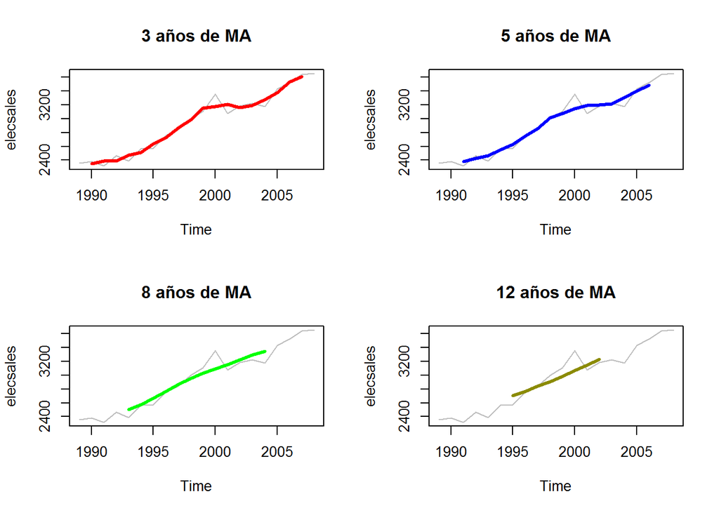

```r
par(mfrow = c(2,2))
plot(elecsales, col="gray", main = "3 años de MA")
lines(ma(elecsales, order = 3), col = "red", lwd=3)
plot(elecsales, col="gray", main = "5 años de MA")
lines(ma(elecsales, order = 5), col = "blue", lwd=3)
plot(elecsales, col="gray", main = "8 años de MA")
lines(ma(elecsales, order = 8), col = "green", lwd=3)
plot(elecsales, col="gray", main = "12 años de MA")
lines(ma(elecsales, order = 12), col = "yellow4", lwd=3)
```

### *Medias móviles centradas: medias móviles sobre medias móviles*

```r
beer2 <- window(ausbeer,start=1980)
ma4 <- ma(beer2, order=4, centre=FALSE)
ma2x4 <- ma(beer2, order=4, centre=TRUE)
```

Comparemos las medias móviles no centradas y centras. ¿Qué podemos concluir?

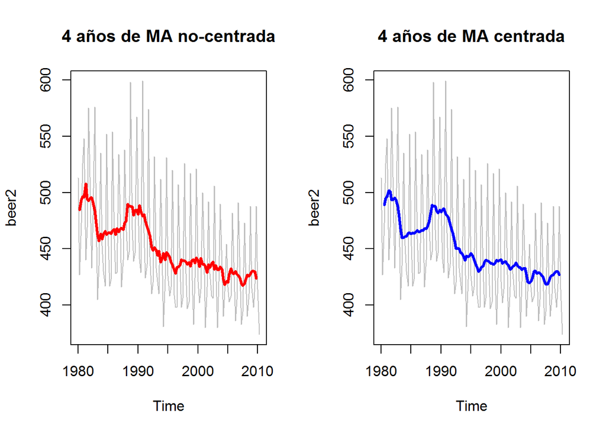

```r
par(mfrow = c(1,2))

plot(beer2, col="gray", main = "4 años de MA no-centrada")
lines(ma(beer2, order=4, centre=FALSE), col = "red", lwd=3)
plot(beer2, col="gray", main = "4 años de MA centrada")
lines(ma(beer2, order=4, centre=TRUE), col = "blue", lwd=3)
```

Otro ejemplo de MA centradas

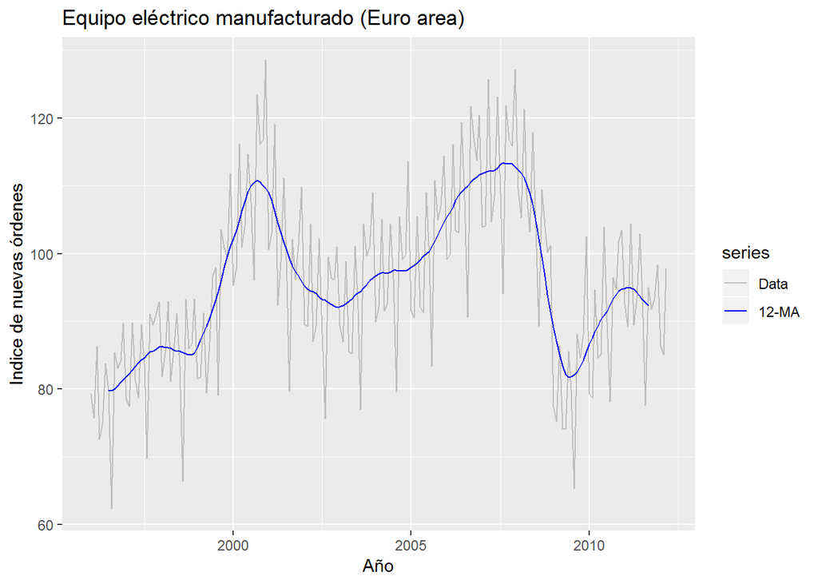

```r
autoplot(elecequip, series="Data") +
  autolayer(ma(elecequip, 12, centre=TRUE), series="12-MA") +
  xlab("Año") + ylab("Indice de nuevas órdenes") +
  ggtitle("Equipo eléctrico manufacturado (Euro area)") +
  scale_colour_manual(values=c("Data"="grey","12-MA"="blue"),
                      breaks=c("Data","12-MA"))
```

### *Conclusión sobre las medias móviles*

En conclusión, por qué es importante utilizar las MA en en análisis de las series temporales.

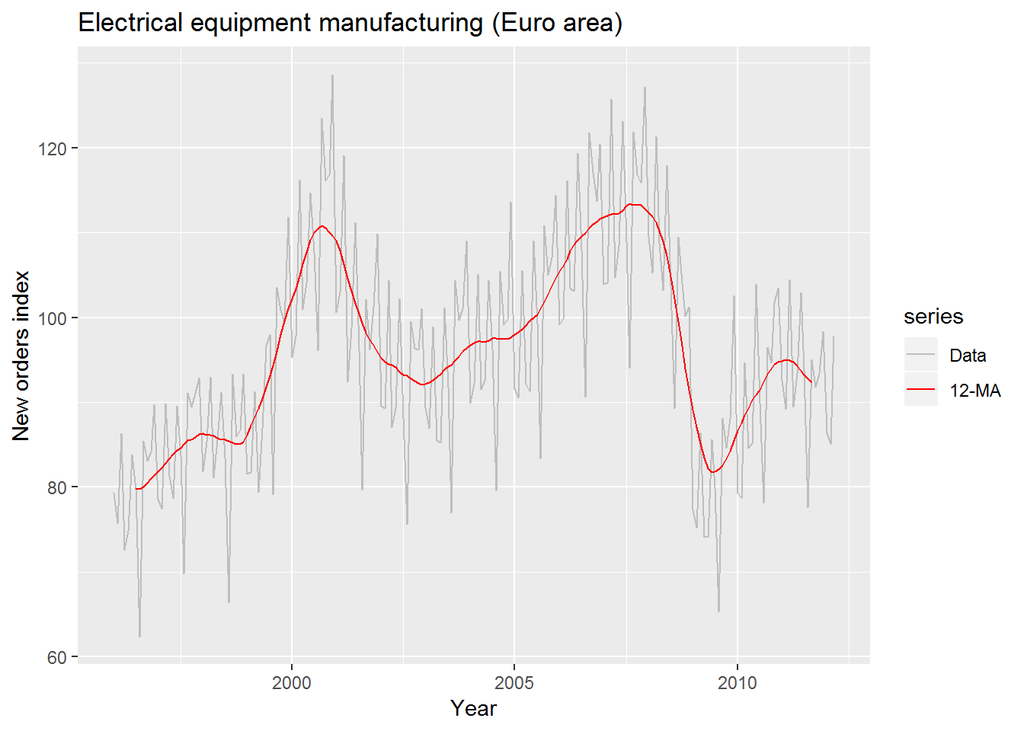

```r
autoplot(elecequip, series="Data") +
  autolayer(ma(elecequip, 12), series="12-MA") +
  xlab("Year") + ylab("New orders index") +
  ggtitle("Electrical equipment manufacturing (Euro area)") +
  scale_colour_manual(values=c("Data"="grey","12-MA"="red"),
                      breaks=c("Data","12-MA"))
```

## Descomposición

### *Descomposición clásica*

Vamos a analizar el Índice de equipamiento eléctrico, del dataset elecequip

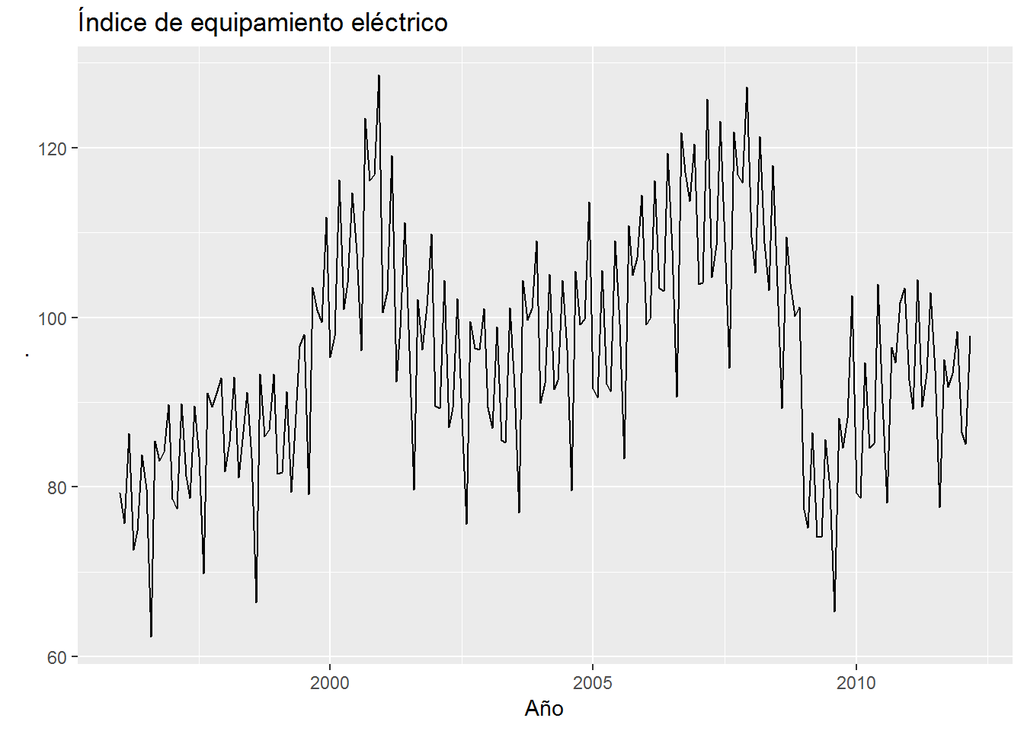

```r
elecequip %>%
  autoplot() + xlab("Año") + ggtitle("Índice de equipamiento eléctrico")
```

#### Descomposición clásica aditiva

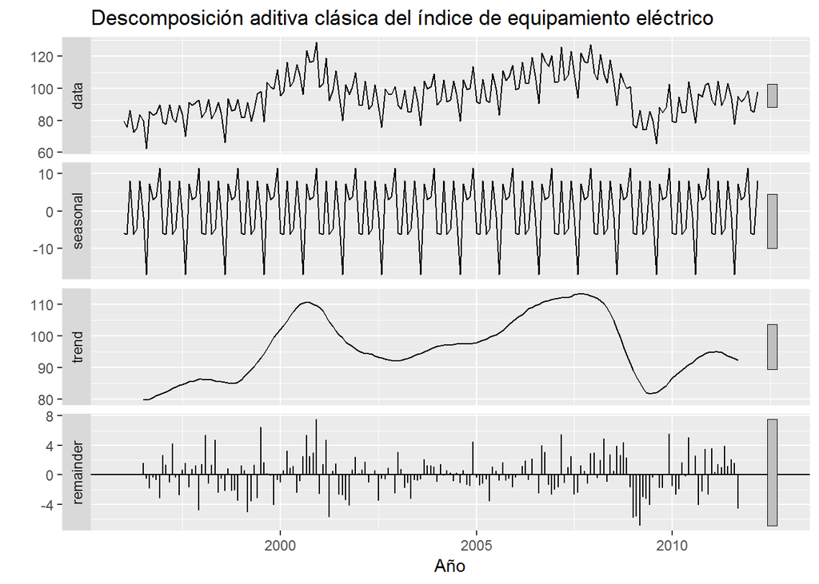

```r
elecequip %>% decompose(type="additive") %>%
  autoplot() + xlab("Año") +
  ggtitle("Descomposición aditiva clásica del índice de equipamiento eléctrico")
```

#### Descomposición clásica multiplicativa

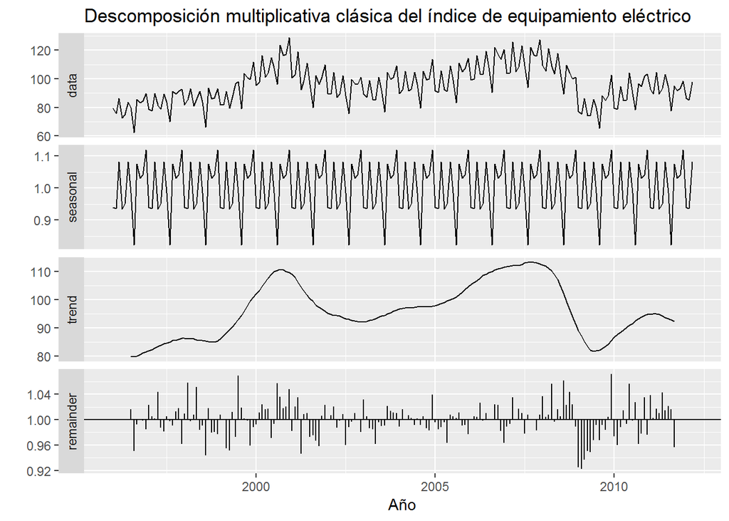

```r
elecequip %>% decompose(type="multiplicative") %>%
  autoplot() + xlab("Año") +
  ggtitle("Descomposición multiplicativa clásica del índice de equipamiento eléctrico")
```

### *Descomposición X-11*

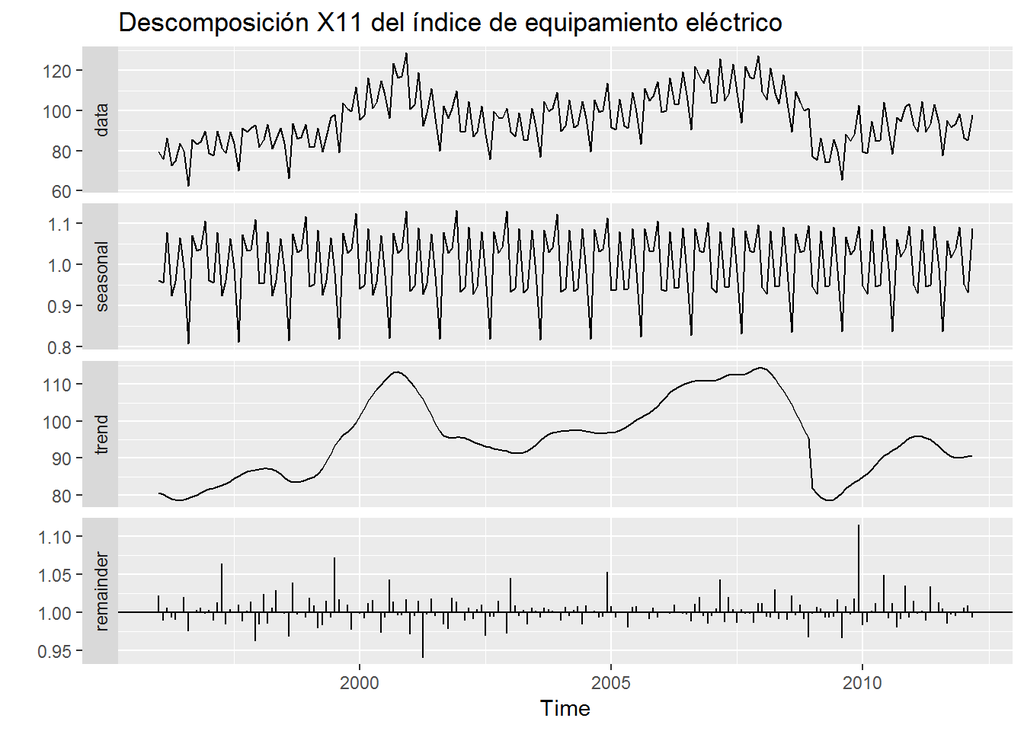

```r
elecequip %>% seas(x11="") -> fit    #utilizo seas(x11="") para invocar el x11
autoplot(fit) + ggtitle("Descomposición X11 del índice de equipamiento eléctrico")
```

Otra forma de ver los efectos mensuales

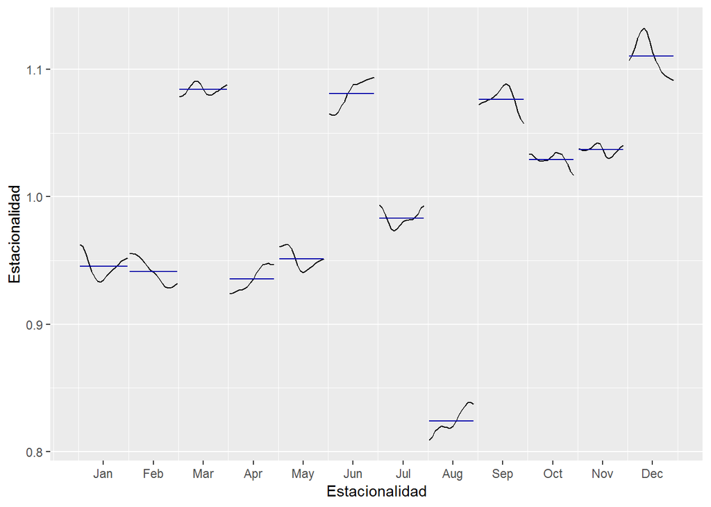

```r
fit %>% seasonal() %>% ggsubseriesplot() + ylab("Estacionalidad") + xlab("Estacionalidad")
```

### *Descomposición SEATS*

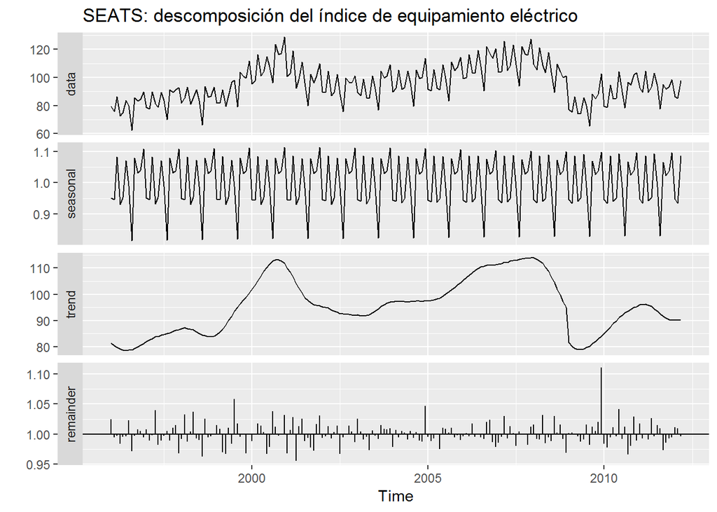

```r
elecequip %>% seas() %>%  #utilizamos la función seas()
  autoplot() +
  ggtitle("SEATS: descomposición del índice de equipamiento eléctrico")
```

### *Descomposición STL*

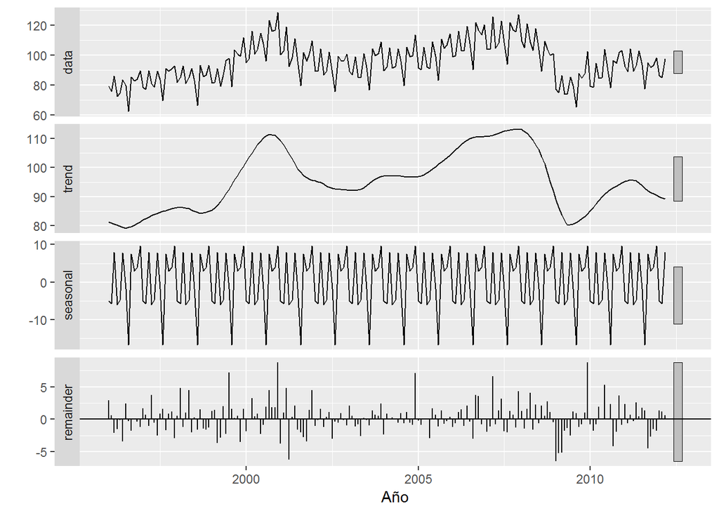

```r
elecequip %>%
  stl(t.window=13, s.window="periodic", robust=TRUE) %>%
  autoplot() + xlab("Año")
```

### *Descomposición: Pronóstico*

Para el pronóstico debemos tomar un método de descomposición. Tomemos el stl()

```r
pronostico <- stl(elecequip, t.window=13, s.window="periodic",
              robust=TRUE)
```

Luego debemos elegir un tipo de método de estimación en el pronóstico. Acá tomamos el método Naive.

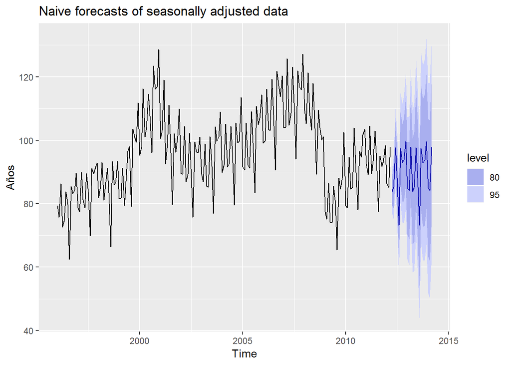

```r
pronostico %>% forecast(method="naive") %>%
         autoplot() + ggtitle("Naive forecasts of seasonally adjusted data") +
         ylab("New orders index")  + ylab("Años")
```

## Los métodos de suavizamiento exponencial

### *Suavizamiento exponencial simple*

Vamos a utilizar datos sobre las ventas de petroleo (millones de toneladas), del dataset oil.

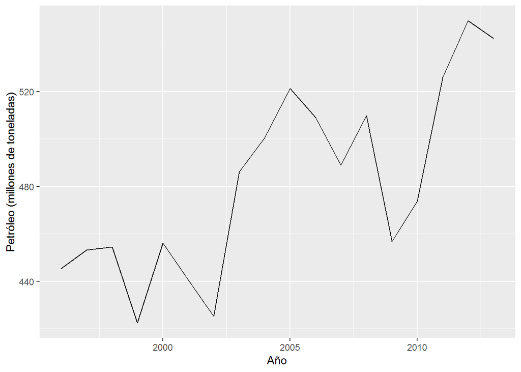

```r
oildata <- window(oil, start=1996)
autoplot(oildata) +  ylab("Petróleo (millones de toneladas)") + xlab("Año")
```

Estimenos un modelo SES

```r
mod.1 <- ses(oildata)
summary(mod.1)
```

```
##
## Forecast method: Simple exponential smoothing
##
## Model Information:
## Simple exponential smoothing
##
## Call:
##  ses(y = oildata)
##
##   Smoothing parameters:
##     alpha = 0.8339
##
##   Initial states:
##     l = 446.5868
##
##   sigma:  29.8282
##
##      AIC     AICc      BIC
## 178.1430 179.8573 180.8141
##
## Error measures:
##                    ME     RMSE     MAE      MPE     MAPE      MASE
## Training set 6.401975 28.12234 22.2587 1.097574 4.610635 0.9256774
##                     ACF1
## Training set -0.03377748
##
## Forecasts:
##      Point Forecast    Lo 80    Hi 80    Lo 95    Hi 95
## 2014       542.6806 504.4541 580.9070 484.2183 601.1429
## 2015       542.6806 492.9073 592.4539 466.5589 618.8023
## 2016       542.6806 483.5747 601.7864 452.2860 633.0752
## 2017       542.6806 475.5269 609.8343 439.9778 645.3834
## 2018       542.6806 468.3452 617.0159 428.9945 656.3667
## 2019       542.6806 461.7988 623.5624 418.9826 666.3786
## 2020       542.6806 455.7439 629.6173 409.7224 675.6388
## 2021       542.6806 450.0841 635.2771 401.0665 684.2947
## 2022       542.6806 444.7509 640.6103 392.9100 692.4511
## 2023       542.6806 439.6935 645.6677 385.1754 700.1858
```

Veamos las medias de rendimiento

```r
round(accuracy(mod.1),2)
```

```
##               ME  RMSE   MAE MPE MAPE MASE  ACF1
## Training set 6.4 28.12 22.26 1.1 4.61 0.93 -0.03
```

Finalmente realicemos los pronósticos. ¿Qué podemos decir?

```r
pronostico.1 <- ses(oildata, h=5)
pronostico.1
```

```
##      Point Forecast    Lo 80    Hi 80    Lo 95    Hi 95
## 2014       542.6806 504.4541 580.9070 484.2183 601.1429
## 2015       542.6806 492.9073 592.4539 466.5589 618.8023
## 2016       542.6806 483.5747 601.7864 452.2860 633.0752
## 2017       542.6806 475.5269 609.8343 439.9778 645.3834
## 2018       542.6806 468.3452 617.0159 428.9945 656.3667
```

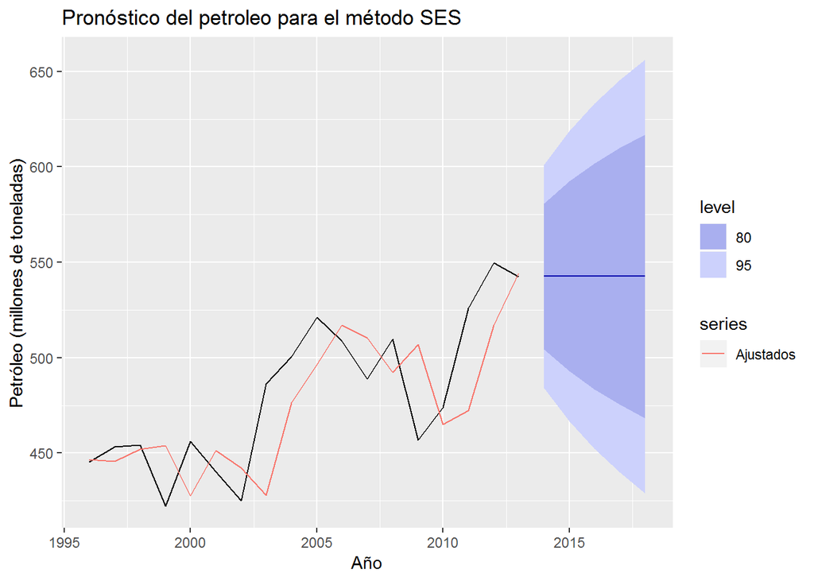

```r
autoplot(pronostico.1) +
  autolayer(fitted(pronostico.1), series="Ajustados") +
  ggtitle("Pronóstico del petroleo para el método SES") +
  ylab("Petróleo (millones de toneladas)") + xlab("Año")
```

### *Método de Holt de la tendencia*

Vamos a utilizar los datos de air, Pasajeros (millones de personas) en Australia.

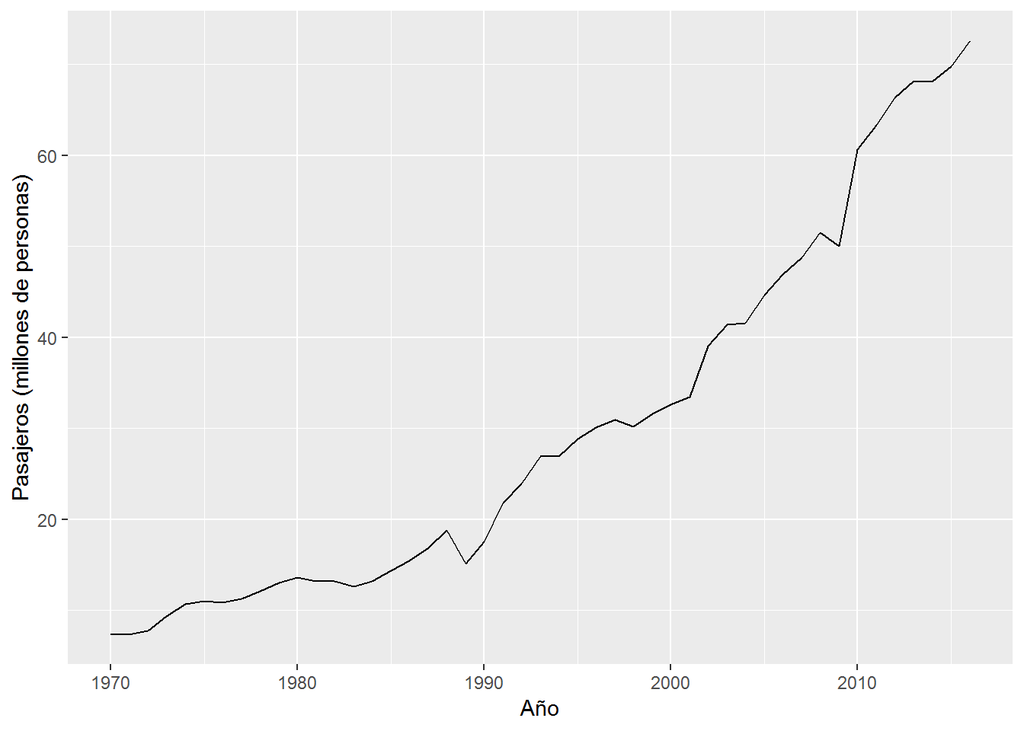

```r
air <- window(ausair, start=1990)
autoplot(ausair) +  ylab("Pasajeros (millones de personas)") + xlab("Año")
```

Estimación del modelo de Holt de tendencia

```r
mod.2 <- holt(air)
summary(mod.2)
```

```
##
## Forecast method: Holt's method
##
## Model Information:
## Holt's method
##
## Call:
##  holt(y = air)
##
##   Smoothing parameters:
##     alpha = 0.8302
##     beta  = 1e-04
##
##   Initial states:
##     l = 15.5715
##     b = 2.1017
##
##   sigma:  2.3645
##
##      AIC     AICc      BIC
## 141.1291 143.9863 147.6083
##
## Error measures:
##                       ME     RMSE     MAE        MPE     MAPE      MASE
## Training set 0.008359331 2.182343 1.52892 -0.3244107 3.820787 0.6654839
##                     ACF1
## Training set -0.01335362
##
## Forecasts:
##      Point Forecast    Lo 80     Hi 80    Lo 95     Hi 95
## 2017       74.60130 71.57106  77.63154 69.96695  79.23566
## 2018       76.70304 72.76440  80.64169 70.67941  82.72668
## 2019       78.80478 74.13092  83.47864 71.65673  85.95284
## 2020       80.90652 75.59817  86.21487 72.78810  89.02494
## 2021       83.00826 77.13343  88.88310 74.02348  91.99305
## 2022       85.11000 78.71857  91.50143 75.33516  94.88485
## 2023       87.21174 80.34235  94.08113 76.70591  97.71757
## 2024       89.31348 81.99718  96.62978 78.12417 100.50280
## 2025       91.41522 83.67768  99.15276 79.58168 103.24876
## 2026       93.51696 85.37987 101.65405 81.07236 105.96157
```

Medidas de rendimiento

```r
round(accuracy(mod.2),2)
```

```
##                ME RMSE  MAE   MPE MAPE MASE  ACF1
## Training set 0.01 2.18 1.53 -0.32 3.82 0.67 -0.01
```

Pronósticos del modelo de Holt con tendencia

```r
pronostico.2 <- holt(air, h=15)
pronostico.2
```

```
##      Point Forecast    Lo 80     Hi 80    Lo 95     Hi 95
## 2017       74.60130 71.57106  77.63154 69.96695  79.23566
## 2018       76.70304 72.76440  80.64169 70.67941  82.72668
## 2019       78.80478 74.13092  83.47864 71.65673  85.95284
## 2020       80.90652 75.59817  86.21487 72.78810  89.02494
## 2021       83.00826 77.13343  88.88310 74.02348  91.99305
## 2022       85.11000 78.71857  91.50143 75.33516  94.88485
## 2023       87.21174 80.34235  94.08113 76.70591  97.71757
## 2024       89.31348 81.99718  96.62978 78.12417 100.50280
## 2025       91.41522 83.67768  99.15276 79.58168 103.24876
## 2026       93.51696 85.37987 101.65405 81.07236 105.96157
## 2027       95.61870 87.10069 104.13671 82.59153 108.64587
## 2028       97.72044 88.83774 106.60314 84.13553 111.30535
## 2029       99.82218 90.58911 109.05525 85.70141 113.94295
## 2030      101.92392 92.35321 111.49463 87.28678 116.56106
## 2031      104.02566 94.12874 113.92257 88.88964 119.16168
```

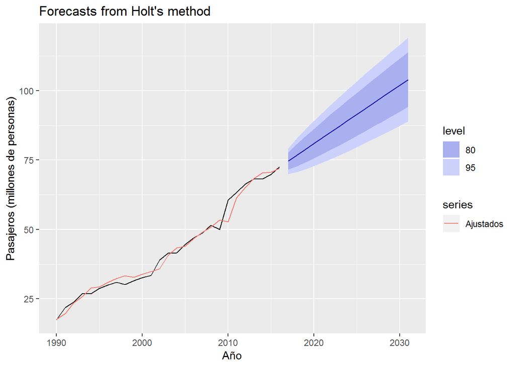

```r
autoplot(pronostico.2) +
  autolayer(fitted(pronostico.2), series="Ajustados") +
  ylab("Pasajeros (millones de personas)") + xlab("Año")
```

Veamos ahora un modelo de Holt con tendencia y amortización. Veamos los resultados de del modelo estimado con amortización

```r
mod.2.2 <- holt(air, damped=TRUE, phi = 0.9)
summary(mod.2.2)
```

```
##
## Forecast method: Damped Holt's method
##
## Model Information:
## Damped Holt's method
##
## Call:
##  holt(y = air, damped = TRUE, phi = 0.9)
##
##   Smoothing parameters:
##     alpha = 0.763
##     beta  = 0.2526
##     phi   = 0.9
##
##   Initial states:
##     l = 14.5766
##     b = 3.7517
##
##   sigma:  2.6165
##
##      AIC     AICc      BIC
## 145.3965 148.2536 151.8757
##
## Error measures:
##                     ME     RMSE      MAE    MPE     MAPE      MASE
## Training set 0.4693536 2.361799 1.512832 0.7805 3.503091 0.6584814
##                     ACF1
## Training set -0.04256712
##
## Forecasts:
##      Point Forecast    Lo 80    Hi 80    Lo 95     Hi 95
## 2017       73.71036 70.35724 77.06348 68.58220  78.83852
## 2018       75.02175 70.30251 79.74098 67.80430  82.23919
## 2019       76.20199 70.01113 82.39285 66.73389  85.67010
## 2020       77.26421 69.53683 84.99160 65.44620  89.08223
## 2021       78.22021 68.91713 87.52330 63.99237  92.44806
## 2022       79.08061 68.18039 89.98084 62.41016  95.75107
## 2023       79.85497 67.34900 92.36095 60.72874  98.98121
## 2024       80.55190 66.44106 94.66274 58.97123 102.13257
## 2025       81.17913 65.47143 96.88683 57.15628 105.20198
## 2026       81.74364 64.45247 99.03480 55.29908 108.18820
```

Las medidas de rendimiento

```r
round(accuracy(mod.2.2),2)
```

```
##                ME RMSE  MAE  MPE MAPE MASE  ACF1
## Training set 0.47 2.36 1.51 0.78  3.5 0.66 -0.04
```

Pronóstico de los métodos de Holt sin y con la amortización (damped)

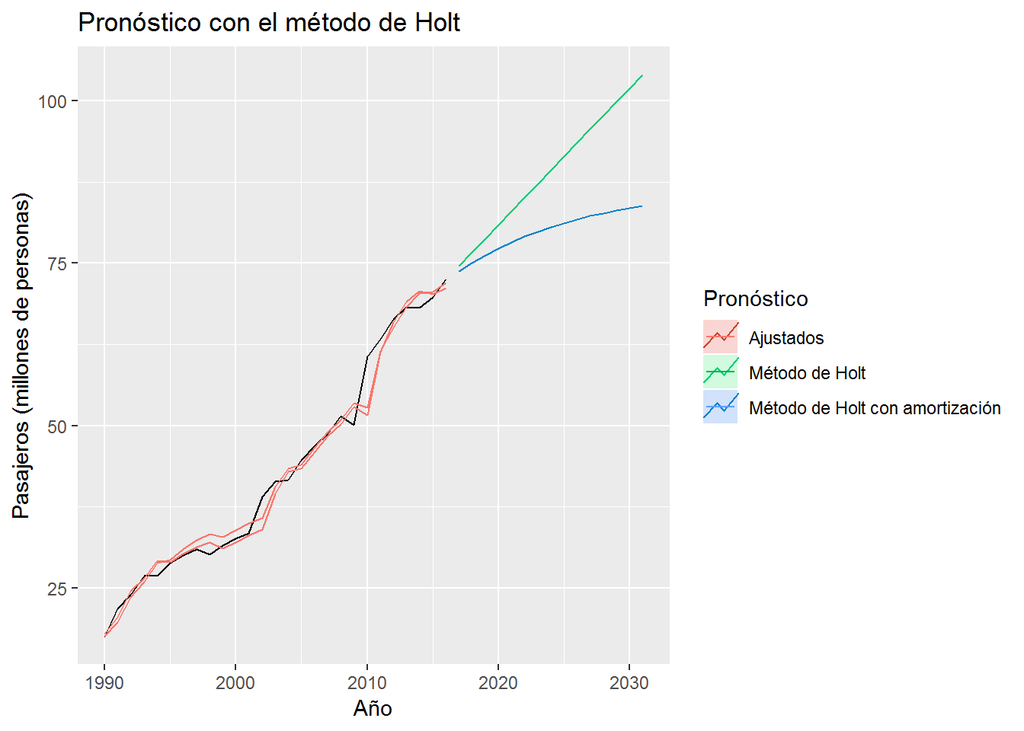

```r
pronostico.2 <- holt(air, h=15)
pronostico.2.2 <- holt(air, damped=TRUE, phi = 0.9, h=15)
autoplot(air) +
  autolayer(pronostico.2, series="Método de Holt", PI=FALSE) +
  autolayer(pronostico.2.2, series="Método de Holt con amortización", PI=FALSE) +
  autolayer(fitted(pronostico.2), series="Ajustados") +
  autolayer(fitted(pronostico.2.2), series="Ajustados") +
  ggtitle("Pronóstico con el método de Holt") + xlab("Año") +
  ylab("Pasajeros (millones de personas)") +
  guides(colour=guide_legend(title="Pronóstico"))
```

### *Holt-Winters estacional*

Vamos a utilizar los famos datosde visita de los turistas, Noches de visitantes (millones), del archivo austourists

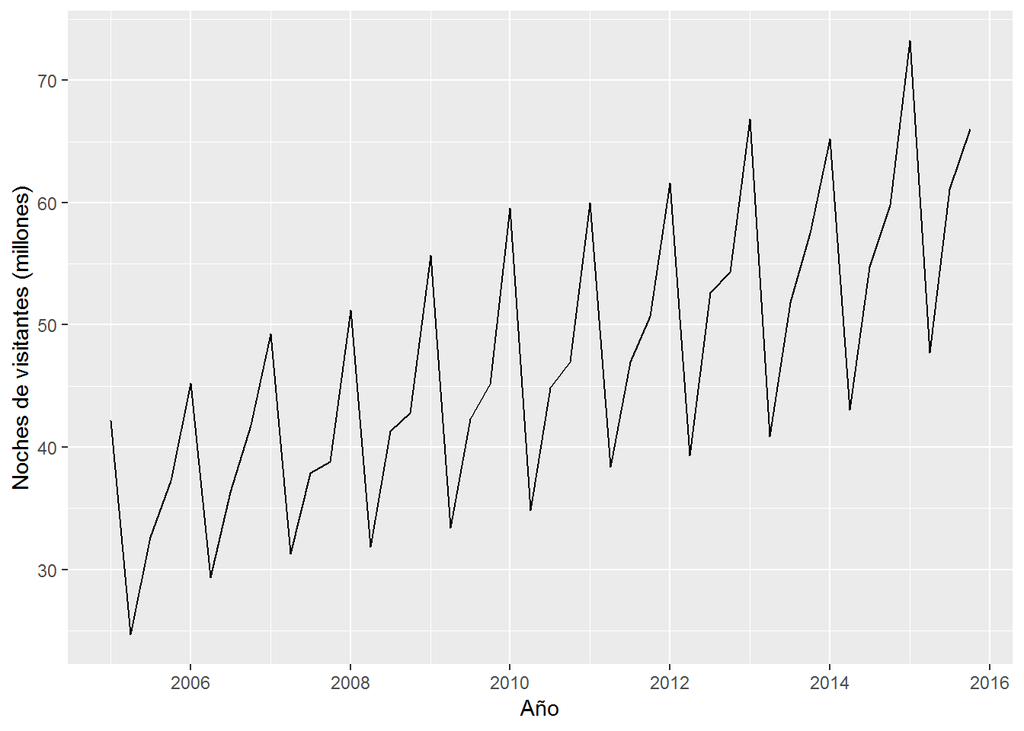

```r
aust <- window(austourists,start=2005)
autoplot(aust) +  ylab("Noches de visitantes (millones)") + xlab("Año")
```

¿Efecto aditivo o multiplicativo? Veamos las dos domalidades

Estimación del modelo Holt-Winters aditivo

```r
fit1 <- hw(aust,seasonal="additive")
summary(fit1)
```

```
##
## Forecast method: Holt-Winters' additive method
##
## Model Information:
## Holt-Winters' additive method
##
## Call:
##  hw(y = aust, seasonal = "additive")
##
##   Smoothing parameters:
##     alpha = 0.3063
##     beta  = 1e-04
##     gamma = 0.4263
##
##   Initial states:
##     l = 32.2597
##     b = 0.7014
##     s = 1.3106 -1.6935 -9.3132 9.6962
##
##   sigma:  1.9494
##
##      AIC     AICc      BIC
## 234.4171 239.7112 250.4748
##
## Error measures:
##                       ME     RMSE      MAE        MPE     MAPE      MASE
## Training set 0.008115785 1.763305 1.374062 -0.2860248 2.973922 0.4502579
##                     ACF1
## Training set -0.06272507
##
## Forecasts:
##         Point Forecast    Lo 80    Hi 80    Lo 95    Hi 95
## 2016 Q1       76.09837 73.60011 78.59664 72.27761 79.91914
## 2016 Q2       51.60333 48.99039 54.21626 47.60718 55.59947
## 2016 Q3       63.96867 61.24582 66.69153 59.80443 68.13292
## 2016 Q4       68.37170 65.54313 71.20027 64.04578 72.69762
## 2017 Q1       78.90404 75.53440 82.27369 73.75061 84.05747
## 2017 Q2       54.40899 50.95325 57.86473 49.12389 59.69409
## 2017 Q3       66.77434 63.23454 70.31414 61.36069 72.18799
## 2017 Q4       71.17737 67.55541 74.79933 65.63806 76.71667
```

Estimación del modelo Holt-Winters multiplicativo

```r
fit2 <- hw(aust,seasonal="multiplicative")
summary(fit2)
```

```
##
## Forecast method: Holt-Winters' multiplicative method
##
## Model Information:
## Holt-Winters' multiplicative method
##
## Call:
##  hw(y = aust, seasonal = "multiplicative")
##
##   Smoothing parameters:
##     alpha = 0.4406
##     beta  = 0.0134
##     gamma = 0.0023
##
##   Initial states:
##     l = 32.4875
##     b = 0.6974
##     s = 1.0237 0.9618 0.7704 1.2442
##
##   sigma:  0.0367
##
##      AIC     AICc      BIC
## 221.1313 226.4254 237.1890
##
## Error measures:
##                      ME     RMSE     MAE           MPE    MAPE      MASE
## Training set 0.09206228 1.575631 1.25496 -0.0006505533 2.70539 0.4112302
##                     ACF1
## Training set -0.07955726
##
## Forecasts:
##         Point Forecast    Lo 80    Hi 80    Lo 95    Hi 95
## 2016 Q1       80.08894 76.31865 83.85922 74.32278 85.85509
## 2016 Q2       50.15482 47.56655 52.74309 46.19640 54.11324
## 2016 Q3       63.34322 59.80143 66.88502 57.92652 68.75993
## 2016 Q4       68.17810 64.08399 72.27221 61.91670 74.43950
## 2017 Q1       83.80112 78.43079 89.17146 75.58790 92.01434
## 2017 Q2       52.45291 48.88795 56.01787 47.00077 57.90504
## 2017 Q3       66.21274 61.46194 70.96353 58.94702 73.47845
## 2017 Q4       71.23205 65.85721 76.60690 63.01194 79.45217
```

Comparación de los rendimientos de ambos modelos

```r
round(accuracy(fit1),2)  #Aditivo
```

```
##                ME RMSE  MAE   MPE MAPE MASE  ACF1
## Training set 0.01 1.76 1.37 -0.29 2.97 0.45 -0.06
```

```r
round(accuracy(fit2),2)  #Multiplicativo
```

```
##                ME RMSE  MAE MPE MAPE MASE  ACF1
## Training set 0.09 1.58 1.25   0 2.71 0.41 -0.08
```

Veamos los pronósticos de los dos métodos

```r
fit1 <- hw(aust,seasonal="additive",h=8)
fit2 <- hw(aust,seasonal="multiplicative", h=8)

fit1;fit2
```

```
##         Point Forecast    Lo 80    Hi 80    Lo 95    Hi 95
## 2016 Q1       76.09837 73.60011 78.59664 72.27761 79.91914
## 2016 Q2       51.60333 48.99039 54.21626 47.60718 55.59947
## 2016 Q3       63.96867 61.24582 66.69153 59.80443 68.13292
## 2016 Q4       68.37170 65.54313 71.20027 64.04578 72.69762
## 2017 Q1       78.90404 75.53440 82.27369 73.75061 84.05747
## 2017 Q2       54.40899 50.95325 57.86473 49.12389 59.69409
## 2017 Q3       66.77434 63.23454 70.31414 61.36069 72.18799
## 2017 Q4       71.17737 67.55541 74.79933 65.63806 76.71667
```

```
##         Point Forecast    Lo 80    Hi 80    Lo 95    Hi 95
## 2016 Q1       80.08894 76.31865 83.85922 74.32278 85.85509
## 2016 Q2       50.15482 47.56655 52.74309 46.19640 54.11324
## 2016 Q3       63.34322 59.80143 66.88502 57.92652 68.75993
## 2016 Q4       68.17810 64.08399 72.27221 61.91670 74.43950
## 2017 Q1       83.80112 78.43079 89.17146 75.58790 92.01434
## 2017 Q2       52.45291 48.88795 56.01787 47.00077 57.90504
## 2017 Q3       66.21274 61.46194 70.96353 58.94702 73.47845
## 2017 Q4       71.23205 65.85721 76.60690 63.01194 79.45217
```

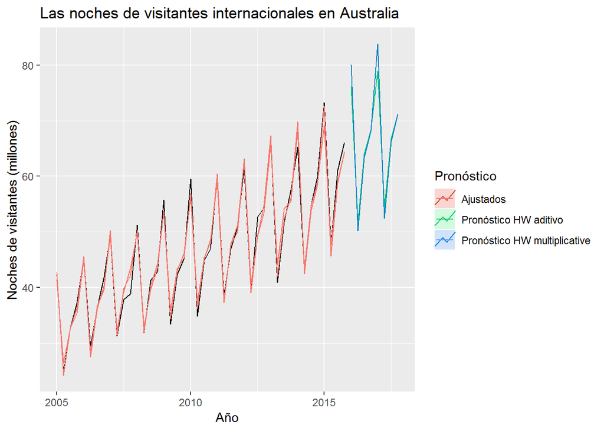

```r
aust <- window(austourists,start=2005)
fit1 <- hw(aust,seasonal="additive")
fit2 <- hw(aust,seasonal="multiplicative")
autoplot(aust) +
  autolayer(fit1, series="Pronóstico HW aditivo", PI=FALSE) +
  autolayer(fit2, series="Pronóstico HW multiplicative",
            PI=FALSE) +
  autolayer(fitted(fit1), series="Ajustados") +
  autolayer(fitted(fit2), series="Ajustados") +
  xlab("Año") +
  ylab("Noches de visitantes (millones)") +
  ggtitle("Las noches de visitantes internacionales en Australia") +
  guides(colour=guide_legend(title="Pronóstico"))
```

Y nos falta la amortización… Estimación de un Holt-Winters con amortización (damped)

Estimación del modelo Holt-Winters multiplicativo amortiguado (damped)

```r
fit3 <- hw(aust,seasonal="multiplicative", damped =TRUE)
round(accuracy(fit3),2)
```

```
##                ME RMSE  MAE  MPE MAPE MASE  ACF1
## Training set 0.27 1.62 1.29 0.37 2.76 0.42 -0.09
```

Pronósticos del modelo multiplicativo con amortiguamiento

```r
fit3 <- hw(aust,seasonal="multiplicative", damped =TRUE, h=10)
fit3
```

```
##         Point Forecast    Lo 80    Hi 80    Lo 95     Hi 95
## 2016 Q1       80.28006 76.34131 84.21880 74.25627  86.30384
## 2016 Q2       50.00751 47.27301 52.74200 45.82546  54.18955
## 2016 Q3       63.66251 59.81647 67.50855 57.78050  69.54452
## 2016 Q4       68.15681 63.64213 72.67149 61.25220  75.06141
## 2017 Q1       83.98684 77.92633 90.04735 74.71809  93.25560
## 2017 Q2       52.23952 48.15764 56.32141 45.99682  58.48223
## 2017 Q3       66.41033 60.82015 72.00050 57.86090  74.95976
## 2017 Q4       71.00271 64.59348 77.41193 61.20064  80.80477
## 2018 Q1       87.38063 78.95582 95.80545 74.49599 100.26527
## 2018 Q2       54.28307 48.71410 59.85204 45.76606  62.80007
```

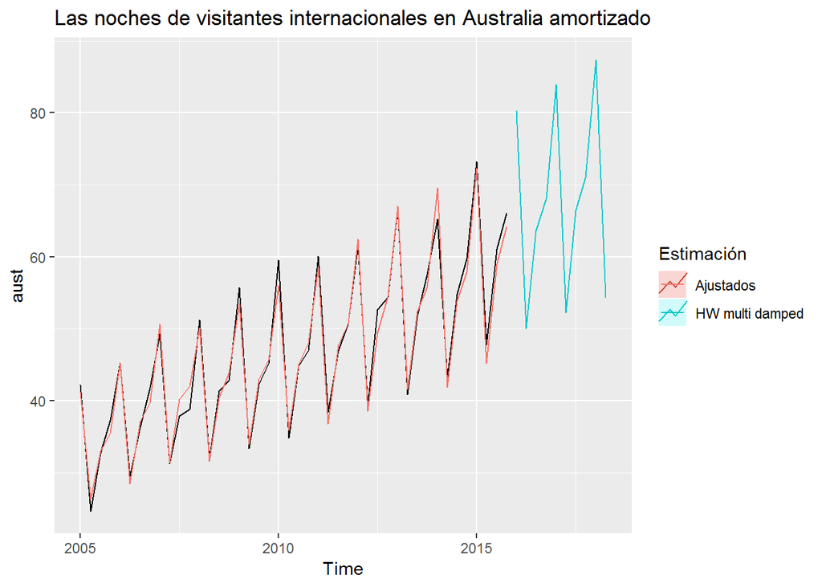

```r
autoplot(aust) +
  autolayer(fit3, series="HW multi damped", PI=FALSE)+
  autolayer(fitted(fit3), series="Ajustados") +
  ggtitle("Las noches de visitantes internacionales en Australia amortizado") +
  guides(colour=guide_legend(title="Estimación"))
```

## Los modelos ETS

### *Suavizamiento exponencial simple con el ETS #*

Vamos a utilizar los datos sobre las ventas del petroleo

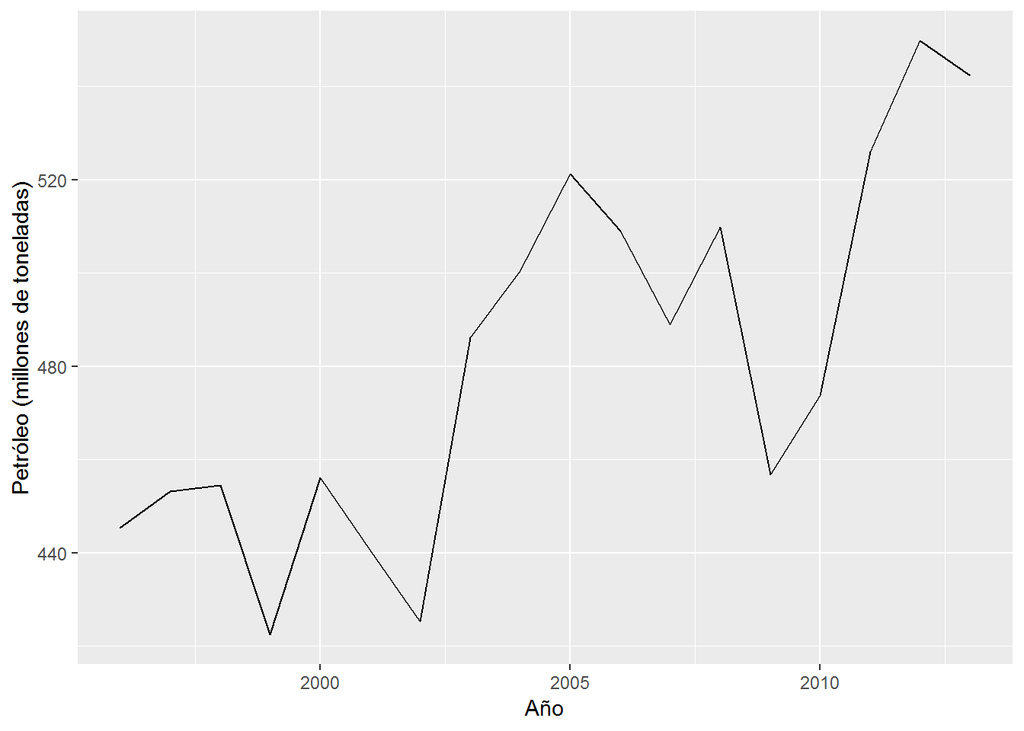

```r
oildata <- window(oil, start=1996)
autoplot(oildata) +  ylab("Petróleo (millones de toneladas)") + xlab("Año")
```

Estimación de modelos SES : de acuerdo a la función ses() y con la ets() suponiendo errores aditivos y multiplicativos

```r
mod.1.1 <- ses(oildata)
summary(mod.1.1)
```

```
##
## Forecast method: Simple exponential smoothing
##
## Model Information:
## Simple exponential smoothing
##
## Call:
##  ses(y = oildata)
##
##   Smoothing parameters:
##     alpha = 0.8339
##
##   Initial states:
##     l = 446.5868
##
##   sigma:  29.8282
##
##      AIC     AICc      BIC
## 178.1430 179.8573 180.8141
##
## Error measures:
##                    ME     RMSE     MAE      MPE     MAPE      MASE
## Training set 6.401975 28.12234 22.2587 1.097574 4.610635 0.9256774
##                     ACF1
## Training set -0.03377748
##
## Forecasts:
##      Point Forecast    Lo 80    Hi 80    Lo 95    Hi 95
## 2014       542.6806 504.4541 580.9070 484.2183 601.1429
## 2015       542.6806 492.9073 592.4539 466.5589 618.8023
## 2016       542.6806 483.5747 601.7864 452.2860 633.0752
## 2017       542.6806 475.5269 609.8343 439.9778 645.3834
## 2018       542.6806 468.3452 617.0159 428.9945 656.3667
## 2019       542.6806 461.7988 623.5624 418.9826 666.3786
## 2020       542.6806 455.7439 629.6173 409.7224 675.6388
## 2021       542.6806 450.0841 635.2771 401.0665 684.2947
## 2022       542.6806 444.7509 640.6103 392.9100 692.4511
## 2023       542.6806 439.6935 645.6677 385.1754 700.1858
```

```r
mod.1.2 <- ets(oildata,model ="ANN" )
summary(mod.1.2)
```

```
## ETS(A,N,N)
##
## Call:
##  ets(y = oildata, model = "ANN")
##
##   Smoothing parameters:
##     alpha = 0.8338
##
##   Initial states:
##     l = 446.5581
##
##   sigma:  29.8282
##
##      AIC     AICc      BIC
## 178.1430 179.8573 180.8141
##
## Training set error measures:
##                    ME     RMSE      MAE      MPE    MAPE     MASE
## Training set 6.404621 28.12234 22.25701 1.098136 4.61025 0.925607
##                     ACF1
## Training set -0.03370615
```

```r
mod.1.3 <- ets(oildata,model ="MNN" )
summary(mod.1.3)
```

```
## ETS(M,N,N)
##
## Call:
##  ets(y = oildata, model = "MNN")
##
##   Smoothing parameters:
##     alpha = 0.7526
##
##   Initial states:
##     l = 445.097
##
##   sigma:  0.0639
##
##      AIC     AICc      BIC
## 178.6203 180.3346 181.2914
##
## Training set error measures:
##                    ME     RMSE      MAE      MPE     MAPE      MASE
## Training set 7.147942 28.19283 22.04476 1.238811 4.554316 0.9167803
##                    ACF1
## Training set 0.02968242
```

Veamos los pronósticos de estos 3 modelos

```r
pronostico.1.1 <- ses(oildata, h=5)
pronostico.1.1
```

```
##      Point Forecast    Lo 80    Hi 80    Lo 95    Hi 95
## 2014       542.6806 504.4541 580.9070 484.2183 601.1429
## 2015       542.6806 492.9073 592.4539 466.5589 618.8023
## 2016       542.6806 483.5747 601.7864 452.2860 633.0752
## 2017       542.6806 475.5269 609.8343 439.9778 645.3834
## 2018       542.6806 468.3452 617.0159 428.9945 656.3667
```

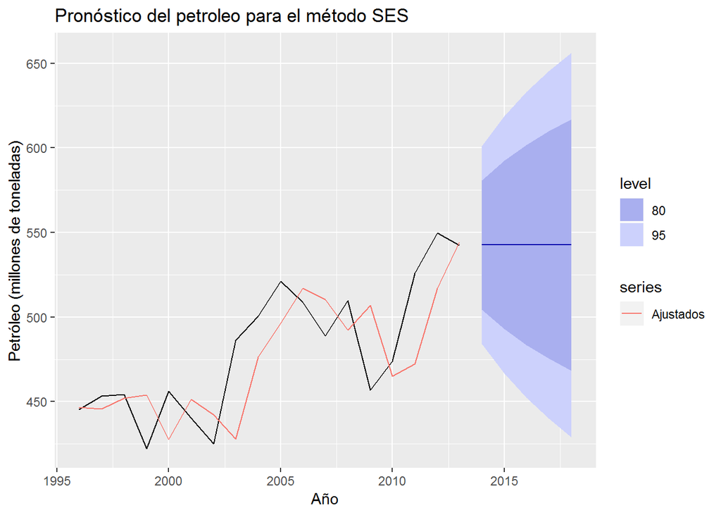

```r
autoplot(pronostico.1.1) +
  autolayer(fitted(pronostico.1.1), series="Ajustados") +
  ggtitle("Pronóstico del petroleo para el método SES") +
  ylab("Petróleo (millones de toneladas)") + xlab("Año")
```

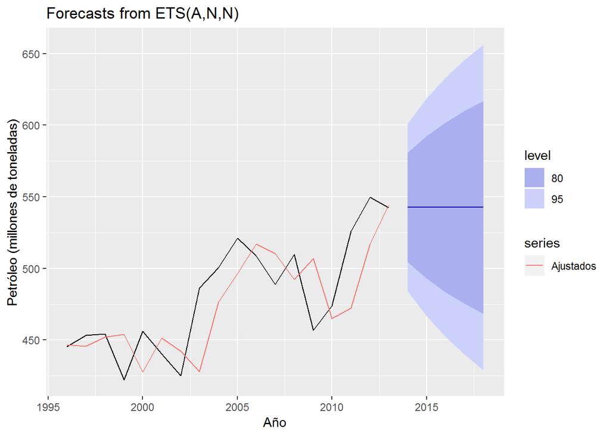

```r
mod.1.2 %>% forecast(h=5) %>%
  autoplot() +
  autolayer(fitted(mod.1.2), series="Ajustados") +
  ylab("Petróleo (millones de toneladas)") + xlab("Año")
```

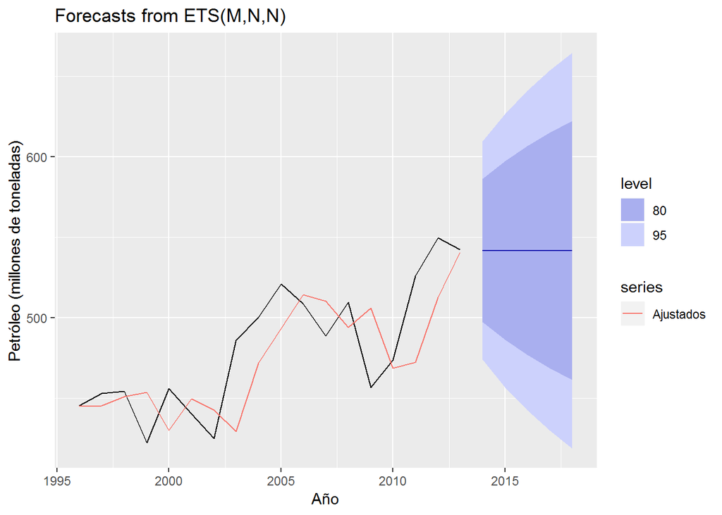

```r
mod.1.3 %>% forecast(h=5) %>%
  autoplot() +
  autolayer(fitted(mod.1.3), series="Ajustados") +
  ylab("Petróleo (millones de toneladas)") + xlab("Año")
```

### *Suavizamiento exponencial con tendencia de Holt mediante el ETS*

Vamos a utilizar los datos de ausair, Pasajeros (millones de personas) en Australia

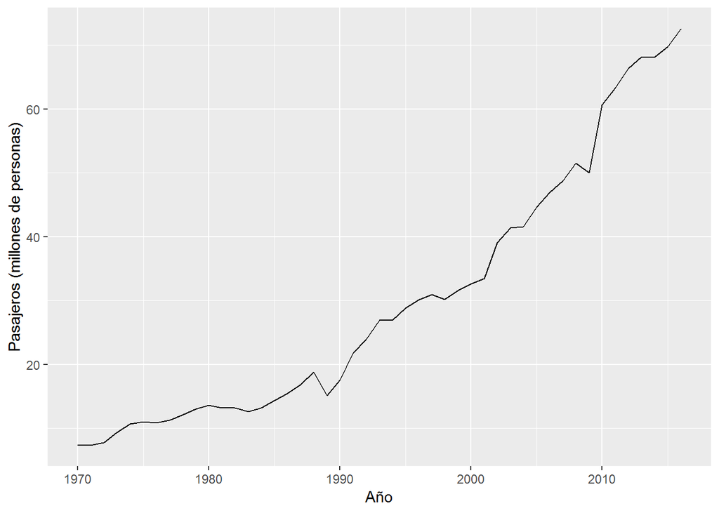

```r
air <- window(ausair, start=1990)
autoplot(ausair) +  ylab("Pasajeros (millones de personas)") + xlab("Año")
```

Veamos la estimación de ambos métodos

Estimación del modelo de Holt de tendencia holt()

```r
mod.2.1 <- holt(air)
summary(mod.2.1)
```

```
##
## Forecast method: Holt's method
##
## Model Information:
## Holt's method
##
## Call:
##  holt(y = air)
##
##   Smoothing parameters:
##     alpha = 0.8302
##     beta  = 1e-04
##
##   Initial states:
##     l = 15.5715
##     b = 2.1017
##
##   sigma:  2.3645
##
##      AIC     AICc      BIC
## 141.1291 143.9863 147.6083
##
## Error measures:
##                       ME     RMSE     MAE        MPE     MAPE      MASE
## Training set 0.008359331 2.182343 1.52892 -0.3244107 3.820787 0.6654839
##                     ACF1
## Training set -0.01335362
##
## Forecasts:
##      Point Forecast    Lo 80     Hi 80    Lo 95     Hi 95
## 2017       74.60130 71.57106  77.63154 69.96695  79.23566
## 2018       76.70304 72.76440  80.64169 70.67941  82.72668
## 2019       78.80478 74.13092  83.47864 71.65673  85.95284
## 2020       80.90652 75.59817  86.21487 72.78810  89.02494
## 2021       83.00826 77.13343  88.88310 74.02348  91.99305
## 2022       85.11000 78.71857  91.50143 75.33516  94.88485
## 2023       87.21174 80.34235  94.08113 76.70591  97.71757
## 2024       89.31348 81.99718  96.62978 78.12417 100.50280
## 2025       91.41522 83.67768  99.15276 79.58168 103.24876
## 2026       93.51696 85.37987 101.65405 81.07236 105.96157
```

Estimación del modelo de Holt de tendencia mediante el ets()

```r
mod.2.2 <- ets(air,  model ="AAN")
summary(mod.2.2)
```

```
## ETS(A,A,N)
##
## Call:
##  ets(y = air, model = "AAN")
##
##   Smoothing parameters:
##     alpha = 0.8302
##     beta  = 1e-04
##
##   Initial states:
##     l = 15.5715
##     b = 2.1017
##
##   sigma:  2.3645
##
##      AIC     AICc      BIC
## 141.1291 143.9863 147.6083
##
## Training set error measures:
##                       ME     RMSE     MAE        MPE     MAPE      MASE
## Training set 0.008359331 2.182343 1.52892 -0.3244107 3.820787 0.6654839
##                     ACF1
## Training set -0.01335362
```

Veamos los pronósticos de ambas estimaciones. Debería ser prácticamente iguale

```r
pronostico.2 <- holt(air, h=15)
pronostico.2
```

```
##      Point Forecast    Lo 80     Hi 80    Lo 95     Hi 95
## 2017       74.60130 71.57106  77.63154 69.96695  79.23566
## 2018       76.70304 72.76440  80.64169 70.67941  82.72668
## 2019       78.80478 74.13092  83.47864 71.65673  85.95284
## 2020       80.90652 75.59817  86.21487 72.78810  89.02494
## 2021       83.00826 77.13343  88.88310 74.02348  91.99305
## 2022       85.11000 78.71857  91.50143 75.33516  94.88485
## 2023       87.21174 80.34235  94.08113 76.70591  97.71757
## 2024       89.31348 81.99718  96.62978 78.12417 100.50280
## 2025       91.41522 83.67768  99.15276 79.58168 103.24876
## 2026       93.51696 85.37987 101.65405 81.07236 105.96157
## 2027       95.61870 87.10069 104.13671 82.59153 108.64587
## 2028       97.72044 88.83774 106.60314 84.13553 111.30535
## 2029       99.82218 90.58911 109.05525 85.70141 113.94295
## 2030      101.92392 92.35321 111.49463 87.28678 116.56106
## 2031      104.02566 94.12874 113.92257 88.88964 119.16168
```

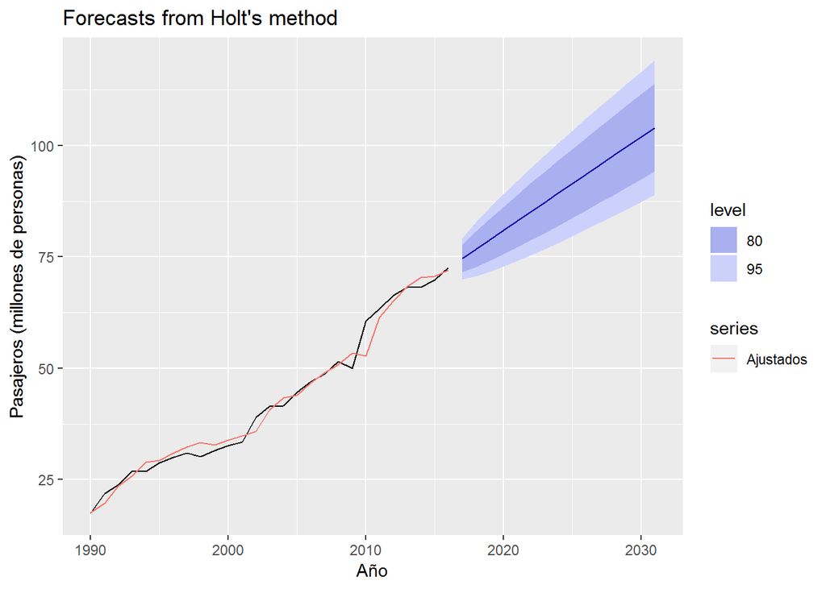

```r
autoplot(pronostico.2) +
  autolayer(fitted(pronostico.2), series="Ajustados") +
  ylab("Pasajeros (millones de personas)") + xlab("Año")
```

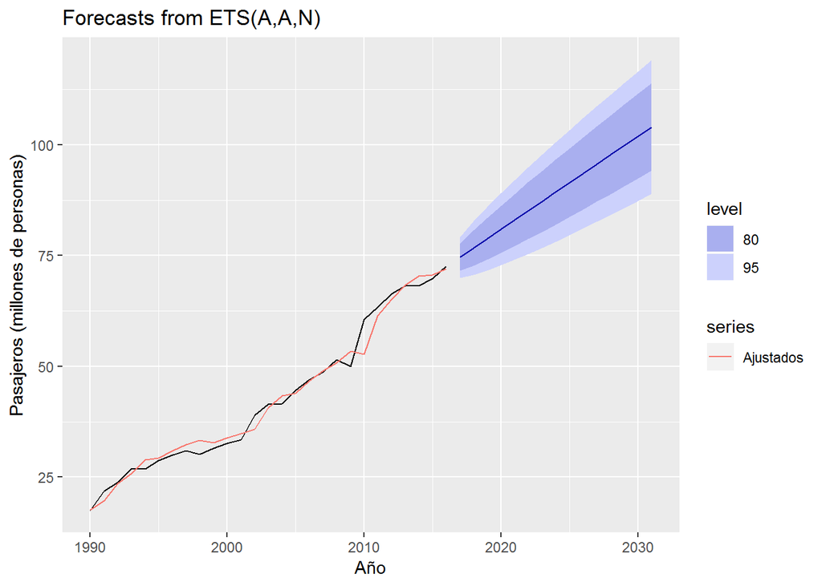

```r
mod.2.2 %>% forecast(h=15) %>%
  autoplot() +
  autolayer(fitted(mod.2.2), series="Ajustados") +
  ylab("Pasajeros (millones de personas)") + xlab("Año")
```

### *Suavizamiento exponencial con tendencia de Holt mediante el ETS y amotiguamiento*

Veamos el ejemplo anterior, suponiendo errores aditivos y amortiguamiento

```r
mod.2.3 <- ets(air,  model ="AAN", damped = TRUE)
summary(mod.2.3)
```

```
## ETS(A,Ad,N)
##
## Call:
##  ets(y = air, model = "AAN", damped = TRUE)
##
##   Smoothing parameters:
##     alpha = 0.8691
##     beta  = 0.0409
##     phi   = 0.98
##
##   Initial states:
##     l = 15.3706
##     b = 2.2225
##
##   sigma:  2.532
##
##      AIC     AICc      BIC
## 145.6239 149.8239 153.3989
##
## Training set error measures:
##                     ME     RMSE      MAE       MPE     MAPE      MASE
## Training set 0.3991612 2.285529 1.529121 0.5606694 3.672846 0.6655715
##                     ACF1
## Training set -0.03141898
```

Veamos como se ven los pronósticos

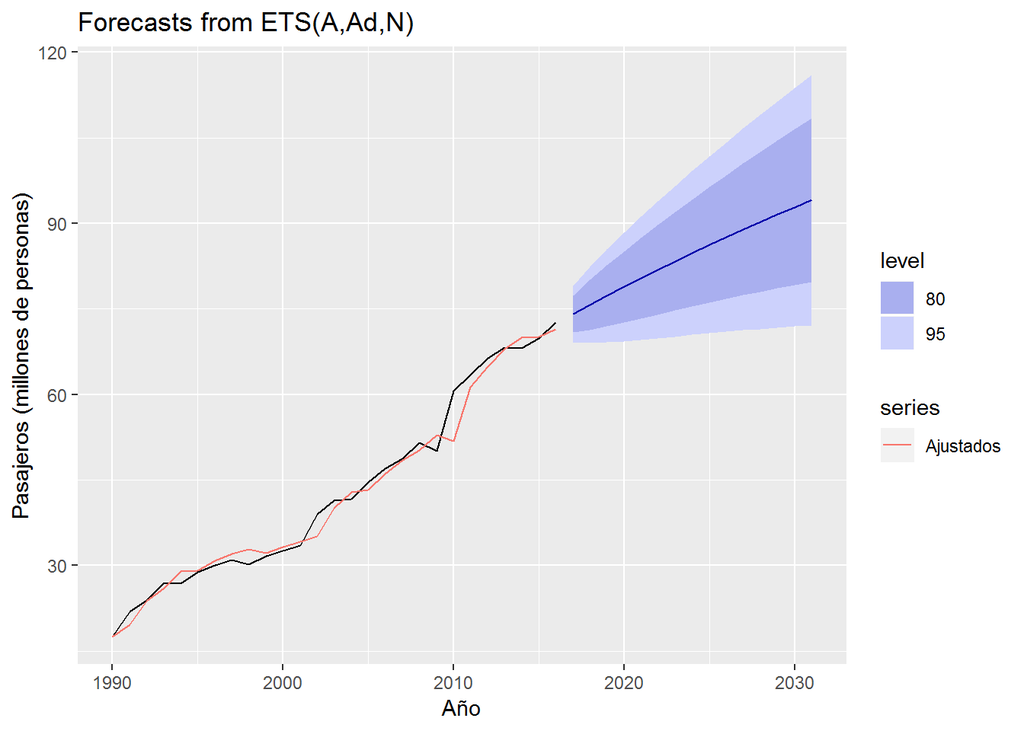

```r
mod.2.3 %>% forecast(h=15) %>%
  autoplot() +                                               # OJO, para el efecto de amortiguamiento
  autolayer(fitted(mod.2.3), series="Ajustados") +           # en la función de ets() se debe marcar
  ylab("Pasajeros (millones de personas)") + xlab("Año")     # damped = TRUE
```

### *Suavizamiento con el Holt-Winter*

Veamos el data set a10, sobre las ventas mensuales de medicamentos antidiabéticos en Australia de 1991 a 2008

```r
head(a10) ; tail(a10)
```

```
##           Jul      Aug      Sep      Oct      Nov      Dec
## 1991 3.526591 3.180891 3.252221 3.611003 3.565869 4.306371
```

```
##           Jan      Feb      Mar      Apr      May      Jun
## 2008 29.66536 21.65429 18.26495 23.10768 22.91251 19.43174
```

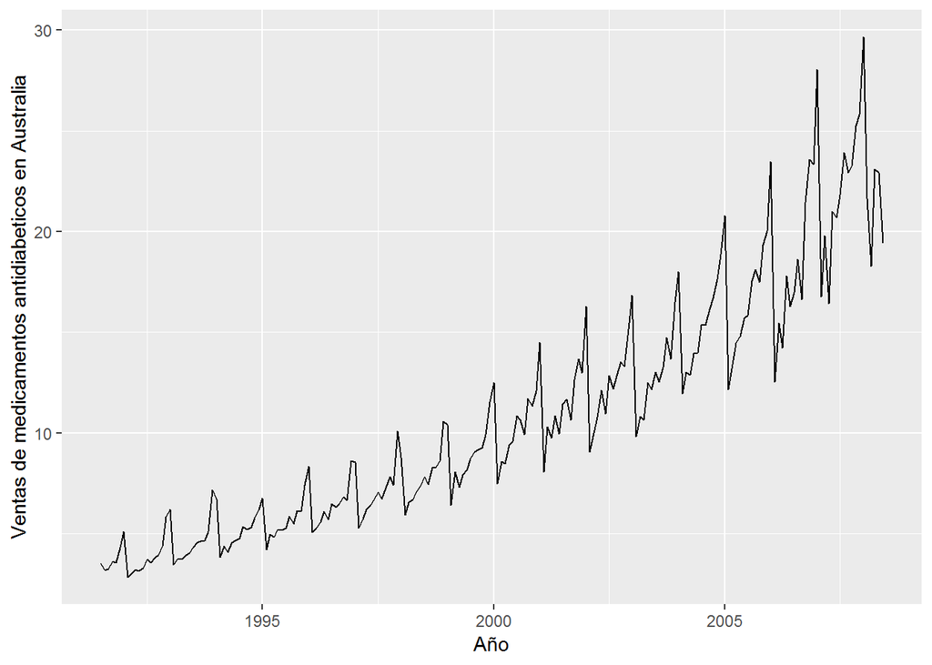

```r
autoplot(a10) +  ylab("Ventas de medicamentos antidiabeticos en Australia") + xlab("Año")
```

```r
mod.3.1 <- hw(a10,seasonal="multiplicative", damped =TRUE)
summary(mod.3.1)
```

```
##
## Forecast method: Damped Holt-Winters' multiplicative method
##
## Model Information:
## Damped Holt-Winters' multiplicative method
##
## Call:
##  hw(y = a10, seasonal = "multiplicative", damped = TRUE)
##
##   Smoothing parameters:
##     alpha = 0.2553
##     beta  = 0.0302
##     gamma = 1e-04
##     phi   = 0.9794
##
##   Initial states:
##     l = 3.1612
##     b = 0.0316
##     s = 0.9027 0.9558 0.8698 0.8664 0.809 1.3102
##            1.1731 1.0909 1.0493 0.9884 1.0095 0.9748
##
##   sigma:  0.0688
##
##      AIC     AICc      BIC
## 911.3631 915.0604 971.0893
##
## Error measures:
##                      ME     RMSE       MAE       MPE     MAPE      MASE
## Training set 0.07888005 0.793317 0.5323887 0.4188026 4.834967 0.4110253
##                    ACF1
## Training set -0.2156101
##
## Forecasts:
##          Point Forecast    Lo 80    Hi 80    Lo 95    Hi 95
## Jul 2008       23.42795 21.36320 25.49271 20.27018 26.58572
## Aug 2008       24.37292 22.13945 26.60639 20.95713 27.78871
## Sep 2008       23.97217 21.67807 26.26628 20.46364 27.48070
## Oct 2008       25.56264 22.99898 28.12631 21.64186 29.48343
## Nov 2008       26.68890 23.87654 29.50126 22.38776 30.99004
## Dec 2008       28.82315 25.62611 32.02018 23.93370 33.71259
## Jan 2009       32.32018 28.54259 36.09777 26.54285 38.09751
## Feb 2009       20.03403 17.56543 22.50263 16.25863 23.80943
## Mar 2009       21.54095 18.74273 24.33917 17.26144 25.82046
## Apr 2009       21.70696 18.73545 24.67847 17.16242 26.25150
## May 2009       23.94058 20.48934 27.39182 18.66237 29.21879
## Jun 2009       22.69368 19.25167 26.13569 17.42958 27.95778
## Jul 2009       24.59045 20.67043 28.51048 18.59530 30.58561
## Aug 2009       25.55191 21.27583 29.82799 19.01221 32.09160
## Sep 2009       25.10275 20.69810 29.50740 18.36643 31.83907
## Oct 2009       26.73819 21.82526 31.65112 19.22451 34.25187
## Nov 2009       27.88579 22.52711 33.24446 19.69041 36.08117
## Dec 2009       30.08380 24.04541 36.12220 20.84888 39.31873
## Jan 2010       33.69900 26.64271 40.75530 22.90734 44.49067
## Feb 2010       20.86776 16.31501 25.42051 13.90493 27.83059
## Mar 2010       22.41550 17.32611 27.50490 14.63194 30.19907
## Apr 2010       22.56682 17.24076 27.89287 14.42132 30.71232
## May 2010       24.86593 18.77236 30.95951 15.54662 34.18525
## Jun 2010       23.54966 17.56395 29.53536 14.39531 32.70401
```

```r
mod.3.2 <- ets(a10,  model ="MAM", damped =TRUE)       # ATENCION A  damped =TRUE
summary(mod.3.2)
```

```
## ETS(M,Ad,M)
##
## Call:
##  ets(y = a10, model = "MAM", damped = TRUE)
##
##   Smoothing parameters:
##     alpha = 0.2524
##     beta  = 0.0379
##     gamma = 1e-04
##     phi   = 0.9643
##
##   Initial states:
##     l = 3.2421
##     b = 0.0569
##     s = 0.9142 0.9346 0.8615 0.8731 0.789 1.3206
##            1.235 1.071 1.043 0.9876 0.99 0.9803
##
##   sigma:  0.0642
##
##      AIC     AICc      BIC
## 882.7384 886.4357 942.4645
##
## Training set error measures:
##                      ME      RMSE       MAE       MPE     MAPE      MASE
## Training set 0.07202848 0.8567787 0.5414404 0.5009925 4.638487 0.4180135
##                   ACF1
## Training set -0.233223
```

Finalmente, veamos como se visualiza el pronóstico

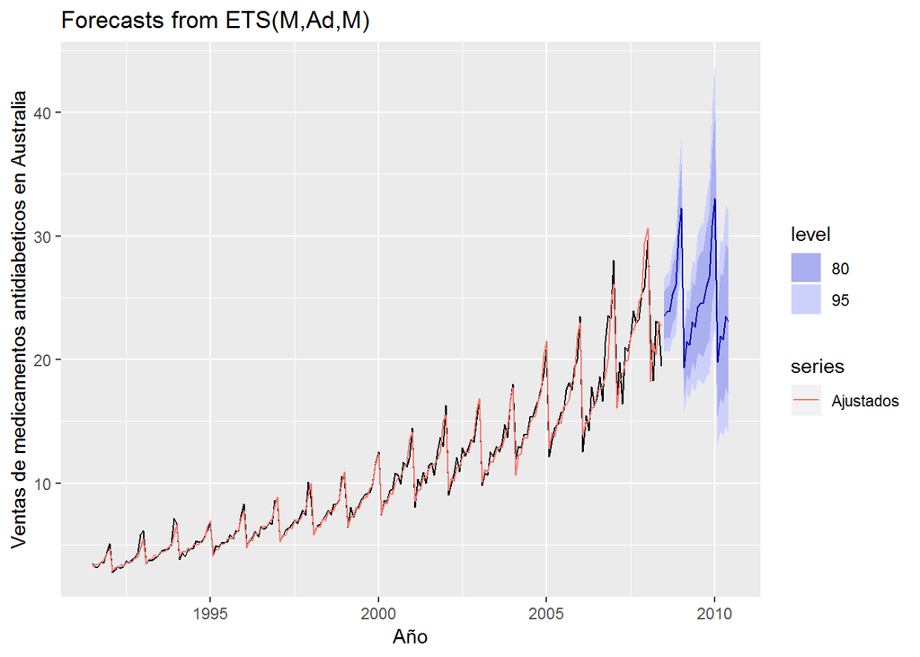

```r
mod.3.2 %>% forecast(h=24) %>%
  autoplot() +
  autolayer(fitted(mod.3.2), series="Ajustados") +
  ylab("Ventas de medicamentos antidiabeticos en Australia") + xlab("Año")
```